# Clase5_py

### Diccionarios

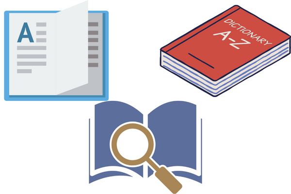

La idea de los diccionarios en **Python** coincide bastante con el concepto de diccionario de la "vida real". Podemos recordar que, en un diccionario, tenemos palabras claves, seguidas de su definición o valor correspondiente.

En **Python** los diccionarios estarán conformados por palabras claves, denominadas *keys*. Donde estas *keys* tendrán un valor asociado, denominado *value*. Así, la estructura de un diccionario se basa en la asociación *key-value*. Por ejemplo, podemos considerar un diccionario que sirva como agenda, de modo que podemos escribir:

- `key`: Lunes || `value`: Estudiar programación en Python
- `key`: Martes || `value`: Partidos de Fut
- `key`: Miércoles || `value`: Salida con amigos
- `key`: Jueves || `value`: Estudiar álgebra
- `key`: Viernes || `value`: Salida con amigos

Ahora, basándonos en la idea *key-value* podemos implementar un diccionario en **Python**, el cual, básicamente, posee la siguiente estructura:

```
<nombre asignado> = {key1: value1, key2: value2, key3: value3, ...}
```

Donde, tanto las llaves (*keys*), como los valores (*values*) pueden ser de distintos tipos de datos. Además, nota que, para definir un diccionario, ocupamos llaves `{}`. Luego, utilizando la agenda que escribimos antes, declaremos nuestro primer diccionario:

```python
# diccionario de la agenda de antes
agenda = {"Lunes": "Estudiar programación en Python", "Martes": "Partidos de Fut",
         "Miércoles": "Salida con amigos", "Jueves": "Estudiar álgeba",
         "Viernes": "Salida con amigos"}

# imprimimos el diccionario anterior
print(agenda)
print()

# tipo de dato de la variable agenda
print(type(agenda))
```

```
{'Lunes': 'Estudiar programación en Python', 'Martes': 'Partidos de Fut', 'Miércoles': 'Salida con amigos', 'Jueves': 'Estudiar álgeba', 'Viernes': 'Salida con amigos'}

<class 'dict'>
```

Antes de continuar, mencionaremos que existe un módulo en **Python** con el cual las impresiones son más visuales para ciertas estructuras de datos. Así, ocuparemos el módulo `pprint` de la librería `pprint` para que la salida de nuestros diccionarios sea un poco más visual. Para ello:

```python
# Importacion
# le damos el alias pp
from pprint import pprint as pp

# Imprimimos utilizando este modulo
# nuestro diccionario
pp(agenda)
```

```
{'Jueves': 'Estudiar álgeba',
 'Lunes': 'Estudiar programación en Python',
 'Martes': 'Partidos de Fut',
 'Miércoles': 'Salida con amigos',
 'Viernes': 'Salida con amigos'}
```

vemos de una manera más estructurada nuestra salida del diccionario `agenda`. No obstante, el orden que nos muestra es un orden alfabético respecto a las cadenas de las *keys*. Para arreglar lo anterior agregamos el parámetro `sort_dicts` y le asignamos el valor de `False` para que la función `pprint` **no** ordene las *keys* de dicha manera de nuestro diccionario, y así se muestre el mismo orden con el cual lo definimos

```python
pp(agenda, sort_dicts = False)
```

```
{'Lunes': 'Estudiar programación en Python',
 'Martes': 'Partidos de Fut',
 'Miércoles': 'Salida con amigos',
 'Jueves': 'Estudiar álgeba',
 'Viernes': 'Salida con amigos'}
```

Podemos obtener también la longitud de un diccionario utilizando la función `len()`

```python
# el cual nos arrojara el numero total de keys
# en nuestro diccionario
print(len(agenda))
```

```
5
```

De manera un poco distinta a las listas o tuplas, podemos acceder a los elementos de un diccionario. Para acceder a las *keys* de los diccionarios, ocupamos corchetes y dentro de ellos el nombre correspondiente a una de las *keys* de dicho diccionario, lo que se nos arrojará será el *value* asociado a dicha *key*.

Por ejemplo, podemos escribir `agenda["Lunes"]` y la salida será el valor `"Estudiar programación en Python"`. En efecto

```python
# imprimimos el value asociado a la key "Lunes"
print(agenda["Lunes"])
print()

# imprimimos el value asociado a la key "Viernes"
print(agenda["Viernes"])
```

```
Estudiar programación en Python

Salida con amigos
```

De manera totalmente análoga a lo anterior, podemos acceder a un valor de una *key* en específico utilizando el método `get()` como sigue

```python
# imprimimos el value asociado a la key "Lunes"
print(agenda.get("Lunes"))
print()

# imprimimos el value asociado a la key "Viernes"
print(agenda.get("Viernes"))
```

```
Estudiar programación en Python

Salida con amigos
```

Podemos cambiar un *value* asociado a una *key*. Por ejemplo, podemos cambiar de `"Estudiar programación en Python"` asociado a la *key* `"Lunes"`, al valor `"Estudiar programación en Java"`. Para ello:

```python
# accedemos al valor de la llave "Lunes" --> agenda["Lunes"]
# asignamos un nuevo valor a esta llave:
agenda["Lunes"] = "Estudiar programación en Java"

# Imprimos el diccionario
pp(agenda, sort_dicts=False)
```

```
{'Lunes': 'Estudiar programación en Java',
 'Martes': 'Partidos de Fut',
 'Miércoles': 'Salida con amigos',
 'Jueves': 'Estudiar álgeba',
 'Viernes': 'Salida con amigos'}
```

```python
print(agenda["Lunes"])
```

```
Estudiar programación en Java
```

Vemos que, justamente, el valor asociado al *Lunes* ha cambiado. De manera muy similar, podemos agregar nuevos *key-value* a nuestros diccionarios. Por ejemplo, podemos agregar:

- `key`: Sábado || `value`: Descansar

Para ello:

```python
# agregamos un nuevo key-value a nuestra agenda:

# creamos una    ||  le asignamos el
# nueva llave    ||  valor descansar
agenda["Sábado"] = "Descansar"

# imprimimos nuestro diccionario
pp(agenda, sort_dicts=False)
```

```
{'Lunes': 'Estudiar programación en Java',
 'Martes': 'Partidos de Fut',
 'Miércoles': 'Salida con amigos',
 'Jueves': 'Estudiar álgeba',
 'Viernes': 'Salida con amigos',
 'Sábado': 'Descansar'}
```

Vemos que se ha agregado la nueva información a nuestro diccionario `agenda`. Podemos acceder a todas las *keys* de nuestro diccionario mediante un bucle `for`:

```python
# imprimimos todas las llaves
# de la agenda:
for _ in agenda:
    print(_, end = "  ")
```

```
Lunes  Martes  Miércoles  Jueves  Viernes  Sábado
```

Para acceder a todas las *keys* y todos los *values* de nuestro diccionario utilizaremos el método `item()`. Al emplear el método `item()` sobre un diccionario, se genera una "colección" de tuplas, en las cuales se hace la correspondencia `(key1, value1), (key2, value2), (key3, value3),...` (notemso que las primeras entradas de las tuplas corresponde a las *keys* y las segundas entradas a los *values*). Así, si escribimos `agenda.items()`, lo que obtendremos será la "colección" de tuplas:

```
('Lunes', 'Estudiar programación en Java'), ('Martes', 'Partidos de Fut'),
('Miércoles', 'Salida con amigos'), ('Jueves', 'Estudiar álgeba'),
('Viernes', 'Salida con amigos'), ('Sábado', 'Descansar')
```

En efecto:

```python
print(agenda.items())
```

```
dict_items([('Lunes', 'Estudiar programación en Java'), ('Martes', 'Partidos de Fut'), ('Miércoles', 'Salida con amigos'), ('Jueves', 'Estudiar álgeba'), ('Viernes', 'Salida con amigos'), ('Sábado', 'Descansar')])
```

De tal manera, podemos emplear un `for`, teniendo ahora dos variables asociadas a este bucle (digamos `i` y `j`), sobre la "colección" `agenda.items()`. Donde la `i` tomará los valores de la primera entrada de las tuplas, es decir, la `i` tomará las *keys*; asimismo, la `j` tomará los *values*

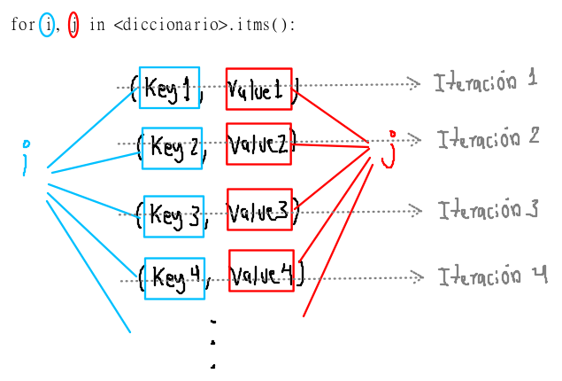

Con base en todo lo anterior , podemos escribir un bucle `for` como sigue:

```python
for i, j in agenda.items():
    print(f"Key: {i} --> Value: {j}")

# u otro ejemplo
print("-" * 60)

for i, j in agenda.items():
    print(f"{i} || {j}")
```

```
Key: Lunes --> Value: Estudiar programación en Java
Key: Martes --> Value: Partidos de Fut
Key: Miércoles --> Value: Salida con amigos
Key: Jueves --> Value: Estudiar álgeba
Key: Viernes --> Value: Salida con amigos
Key: Sábado --> Value: Descansar
------------------------------------------------------------
Lunes || Estudiar programación en Java
Martes || Partidos de Fut
Miércoles || Salida con amigos
Jueves || Estudiar álgeba
Viernes || Salida con amigos
Sábado || Descansar
```

Podemos utilizar lo aprendido sobre los formatos para hacer algo como

```python
# Podemos darle un poco mas de formato, algo
# asi como una tabla:

# declaramos una variable que almacene 40 guiones
guiones = "-" * 51

# Primer columna
print(f"|{guiones}|")
print("|{:^15}|{:^35}|".format("DÍA", "TAREA"))
print(f"|{guiones}|")

# iteramos
for i, j in agenda.items():
    # alineamos al centro con ^
    print("|{:^15}|{:^35}|".format(i, j))
    print(f"|{guiones}|")
```

```
|---------------------------------------------------|
|      DÍA      |               TAREA               |
|---------------------------------------------------|
|     Lunes     |   Estudiar programación en Java   |
|---------------------------------------------------|
|    Martes     |          Partidos de Fut          |
|---------------------------------------------------|
|   Miércoles   |         Salida con amigos         |
|---------------------------------------------------|
|    Jueves     |          Estudiar álgeba          |
|---------------------------------------------------|
|    Viernes    |         Salida con amigos         |
|---------------------------------------------------|
|    Sábado     |             Descansar             |
|---------------------------------------------------|
```

Por otro lado, así como el método `items()` nos arroja una "colección" de tuplas de la forma `(key x, value x)`, donde $x=1,2,..$. Tenemos un método similar para extraer solamente o las *keys* o los *values*. Esto es, si ocupamos el método `keys()` sobre un diccionario, obtenemos una "colección" de todas las *keys* de dicho diccionario. Por ejemplo

```python
# para el diccionario agenda
print(agenda.keys())
```

```
dict_keys(['Lunes', 'Martes', 'Miércoles', 'Jueves', 'Viernes', 'Sábado'])
```

Si ocupamos el método `values()` sobre un diccionario, obtenemos una "colección" de todas los *values* de dicho diccionario. Por ejemplo

```python
# para el diccionario agenda
print(agenda.values())
```

```
dict_values(['Estudiar programación en Java', 'Partidos de Fut', 'Salida con amigos', 'Estudiar álgeba', 'Salida con amigos', 'Descansar'])
```

Así, podemos iterar sobre éstos:

```python
# para las llaves:
for i in agenda.keys():
    print(f"Esto es una llave: {i}")

# o tambien denomiando a la variable
# del bucle de una manera mas concorde
# a lo que se esta haciendo
print("-" * 30)
for key in agenda.keys():
    print(f"Esto es una llave: {key}")
```

```
Esto es una llave: Lunes
Esto es una llave: Martes
Esto es una llave: Miércoles
Esto es una llave: Jueves
Esto es una llave: Viernes
Esto es una llave: Sábado
------------------------------
Esto es una llave: Lunes
Esto es una llave: Martes
Esto es una llave: Miércoles
Esto es una llave: Jueves
Esto es una llave: Viernes
Esto es una llave: Sábado
```

```python
# para los valores:
for value in agenda.values():
    print(f"Esto es un valor: {value}")
```

```
Esto es un valor: Estudiar programación en Java
Esto es un valor: Partidos de Fut
Esto es un valor: Salida con amigos
Esto es un valor: Estudiar álgeba
Esto es un valor: Salida con amigos
Esto es un valor: Descansar
```